# Part_2_Regression

2024-04-11

## Load packages

This example uses the `tidyverse` suite of packages.

```r
library(tidyverse)
```

```r
library(corrplot)
library(coefplot)
library(splines)
library(caret)
```

## Regression task

```r
df <- readr::read_csv("paint_project_train_data.csv", col_names = TRUE)
df %>% glimpse()
```

```
## Rows: 835
## Columns: 8
## $ R          <dbl> 172, 26, 172, 28, 170, 175, 90, 194, 171, 122, 0, 88, 144, …
## $ G          <dbl> 58, 88, 94, 87, 66, 89, 78, 106, 68, 151, 121, 140, 82, 163…
## $ B          <dbl> 62, 151, 58, 152, 58, 65, 136, 53, 107, 59, 88, 58, 132, 50…
## $ Lightness  <chr> "dark", "dark", "dark", "dark", "dark", "dark", "dark", "da…
## $ Saturation <chr> "bright", "bright", "bright", "bright", "bright", "bright",…
## $ Hue        <dbl> 4, 31, 8, 32, 5, 6, 34, 10, 1, 21, 24, 22, 36, 16, 26, 12, …
## $ response   <dbl> 12, 10, 16, 10, 11, 16, 10, 19, 14, 25, 14, 19, 14, 38, 15,…
## $ outcome    <dbl> 1, 1, 1, 0, 0, 0, 0, 0, 0, 0, 0, 0, 0, 0, 0, 0, 0, 0, 1, 1,…
```

As stated in the project guidelines, you will **not** model the continuous output, `response`, directly. The `response` is a bounded variable between 0 and 100. The `response` must be transformed to an unbounded variable to appropriately be modeled by a Gaussian likelihood. We are making this transformation because we want the **uncertainty** in the predicted output to also satisfy output constraints. If we did not make this transformation the uncertainty could violate the bounds, which would mean the model is providing unphysical results! By logit-transforming `response`, we will fully respect the bounds of the output variable.

The code chunk below assembles the data for Part ii) of the project. You should use this data set for all regression modeling tasks. The logit-transformed output is named `y`. The `dfii` dataframe as the original `response` and Binary output, `outcome`, removed. This way you can focus on the variables specific to the regression task.

```r
dfii <- df %>%
  mutate(y = boot::logit( (response - 0) / (100 - 0) ) ) %>%
  select(R, G, B,
         Lightness, Saturation, Hue,
         y)

dfii
```

```
## # A tibble: 835 × 7
##        R     G     B Lightness Saturation   Hue     y
##    <dbl> <dbl> <dbl> <chr>     <chr>      <dbl> <dbl>
##  1   172    58    62 dark      bright         4 -1.99
##  2    26    88   151 dark      bright        31 -2.20
##  3   172    94    58 dark      bright         8 -1.66
##  4    28    87   152 dark      bright        32 -2.20
##  5   170    66    58 dark      bright         5 -2.09
##  6   175    89    65 dark      bright         6 -1.66
##  7    90    78   136 dark      bright        34 -2.20
##  8   194   106    53 dark      bright        10 -1.45
##  9   171    68   107 dark      bright         1 -1.82
## 10   122   151    59 dark      bright        21 -1.10
## # ℹ 825 more rows
```

**Important**: It is up to you as to whether further preprocessing of the inputs are required before fitting the models.

### Simple model

You are going to fit many models in this project. Rather than having a single large RMarkdown that fits all models, it can be useful to work in a modular fashion. You can have separate RMarkdowns for different portions of the project. You can fit/train models, save them, and then load them in other RMarkdowns as needed. This example RMarkdown shows how to fit a simple linear model just to show the process of saving and loading the model object back in.

mod01 - ##Intercept-only model – no INPUTS! mod02 - Categorical variables only – linear additive mod03 - Continuous variables only – linear additive mod04 - All categorical and continuous variables – linear additive mod05 - Interaction of the categorical inputs with all continuous inputs main effects mod06 - Add categorical inputs to all main effect and all pairwise interactions of continuous inputs mod07 - Interaction of the categorical inputs with all main effect and all pairwise interactions of continuous inputs 3 models with basis functions of your choice mod08 - Try non-linear basis functions based on your EDA. mod09 - Can consider interactions of basis functions with other basis functions! mod10 - Can consider interactions of basis functions with the categorical inputs! ###

```r
mod01 <- lm( y ~ 1, data = dfii )
mod02 <- lm( y ~ Lightness + Saturation, data = dfii)
mod03 <- lm(y ~ R + G + B + Hue, data = dfii)
mod04 <- lm(y ~ R + G + B + Lightness + Saturation + Hue, data = dfii)
mod05 <- lm(y ~ (Lightness + Saturation) * (R + G + B + Hue), data = dfii)
mod06 <- lm(y ~ Lightness + Saturation + R + G + B + Hue +
              R:G + R:B + G:B + R:Hue + G:Hue + B:Hue, data = dfii)
mod07 <- lm(y ~ (Lightness + Saturation) * (R + G + B + Hue +
              R:G + R:B + G:B + R:Hue + G:Hue + B:Hue), data = dfii)
mod08 <- lm(y ~ poly(R, 2) + poly(G, 2) + poly(B, 2) + poly(Hue, 2) + Lightness + Saturation, data = dfii)
mod09 <- lm(y ~ (poly(R, 2) + poly(G, 2) + poly(B, 2) + poly(Hue, 2))^2 + Lightness + Saturation, data = dfii)
mod10 <- lm(y ~ (poly(R, 2) + poly(G, 2) + poly(B, 2) + poly(Hue, 2)) * (Lightness + Saturation), data = dfii)
```

```r
mod01 %>% readr::write_rds("my_mod01.rds")
mod02 %>% readr::write_rds("my_mod02.rds")
mod03 %>% readr::write_rds("my_mod03.rds")
mod04 %>% readr::write_rds("my_mod04.rds")
mod05 %>% readr::write_rds("my_mod05.rds")
mod06 %>% readr::write_rds("my_mod06.rds")
mod07 %>% readr::write_rds("my_mod07.rds")
mod08 %>% readr::write_rds("my_mod08.rds")
mod09 %>% readr::write_rds("my_mod09.rds")
mod10 %>% readr::write_rds("my_mod10.rds")
```

```r
re_load_mod01 <- readr::read_rds("my_mod01.rds")
re_load_mod02 <- readr::read_rds("my_mod02.rds")
re_load_mod03 <- readr::read_rds("my_mod03.rds")
re_load_mod04 <- readr::read_rds("my_mod04.rds")
re_load_mod05 <- readr::read_rds("my_mod05.rds")
re_load_mod06 <- readr::read_rds("my_mod06.rds")
re_load_mod07 <- readr::read_rds("my_mod07.rds")
re_load_mod08 <- readr::read_rds("my_mod08.rds")
re_load_mod09 <- readr::read_rds("my_mod09.rds")
re_load_mod10 <- readr::read_rds("my_mod10.rds")
```

```r
re_load_mod01 %>% class()
```

```
## [1] "lm"
```

```r
re_load_mod02 %>% class()
```

```
## [1] "lm"
```

```r
re_load_mod03 %>% class()
```

```
## [1] "lm"
```

```r
re_load_mod04 %>% class()
```

```
## [1] "lm"
```

```r
re_load_mod05 %>% class()
```

```
## [1] "lm"
```

```r
re_load_mod06 %>% class()
```

```
## [1] "lm"
```

```r
re_load_mod07 %>% class()
```

```
## [1] "lm"
```

```r
re_load_mod08 %>% class()
```

```
## [1] "lm"
```

```r
re_load_mod09 %>% class()
```

```
## [1] "lm"
```

```r
re_load_mod10 %>% class()
```

```
## [1] "lm"
```

Which of the 10 models is the best? • What performance metric did you use to make your selection? ### Sol:mod09 is considered the best, since it has lowest AIC value.

```r
extract_metrics <- function(mod, mod_name)
{
broom::glance(mod) %>%
    mutate(mod_name = mod_name)
}

all_metrics <- purrr::map2_dfr(list(mod01, mod02, mod03, mod04, mod05, mod06,mod07,mod08,mod09,mod10),
as.character(1:10),
extract_metrics)

all_metrics %>% glimpse()
```

```
## Rows: 10
## Columns: 13
## $ r.squared     <dbl> 0.0000000, 0.8846326, 0.9881038, 0.9945082, 0.9978083, 0…
## $ adj.r.squared <dbl> 0.0000000, 0.8829484, 0.9880465, 0.9944008, 0.9976262, 0…
## $ sigma         <dbl> 1.18434210, 0.40519660, 0.12948675, 0.08862198, 0.057703…
## $ statistic     <dbl> NA, 525.2554, 17235.0403, 9258.1844, 5477.4752, 8494.316…
## $ p.value       <dbl> NA, 0, 0, 0, 0, 0, 0, 0, 0, 0
## $ df            <dbl> NA, 12, 4, 16, 64, 22, 142, 20, 44, 116
## $ logLik        <dbl> -1325.5849, -423.9378, 524.5814, 847.2924, 1230.8036, 94…
## $ AIC           <dbl> 2655.1698, 875.8757, -1037.1628, -1658.5849, -2329.6072,…
## $ BIC           <dbl> 2664.6246, 942.0597, -1008.7982, -1573.4911, -2017.5967,…
## $ deviance      <dbl> 1169.823619, 134.959484, 13.916459, 6.424454, 2.563881, …
## $ df.residual   <int> 834, 822, 830, 818, 770, 812, 692, 814, 790, 718
## $ nobs          <int> 835, 835, 835, 835, 835, 835, 835, 835, 835, 835
## $ mod_name      <chr> "1", "2", "3", "4", "5", "6", "7", "8", "9", "10"
```

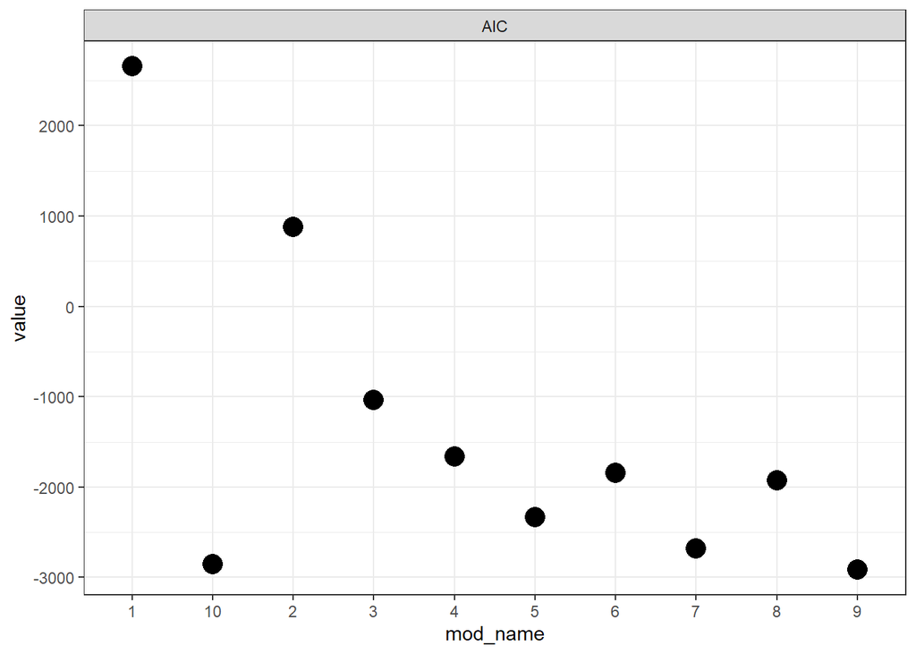

```r
all_metrics %>%
select(mod_name, df, AIC) %>%
pivot_longer(!c("mod_name", "df")) %>%
ggplot(mapping = aes(x = mod_name, y = value)) +
geom_point(size = 5) +
facet_wrap(~name, scales = "free_y") +
theme_bw()
```

```r
top_models <- all_metrics %>%
  arrange(AIC) %>%
  slice_head(n = 3) %>%
  select(mod_name, r.squared, adj.r.squared, AIC, BIC, nobs)
top_models
```

```
## # A tibble: 3 × 6
##   mod_name r.squared adj.r.squared    AIC    BIC  nobs
##   <chr>        <dbl>         <dbl>  <dbl>  <dbl> <int>
## 1 9            0.999         0.999 -2917. -2700.   835
## 2 10           0.999         0.999 -2855. -2297.   835
## 3 7            0.999         0.999 -2683. -2002.   835
```

Visualize the coefficient summaries for your top 3 models ###

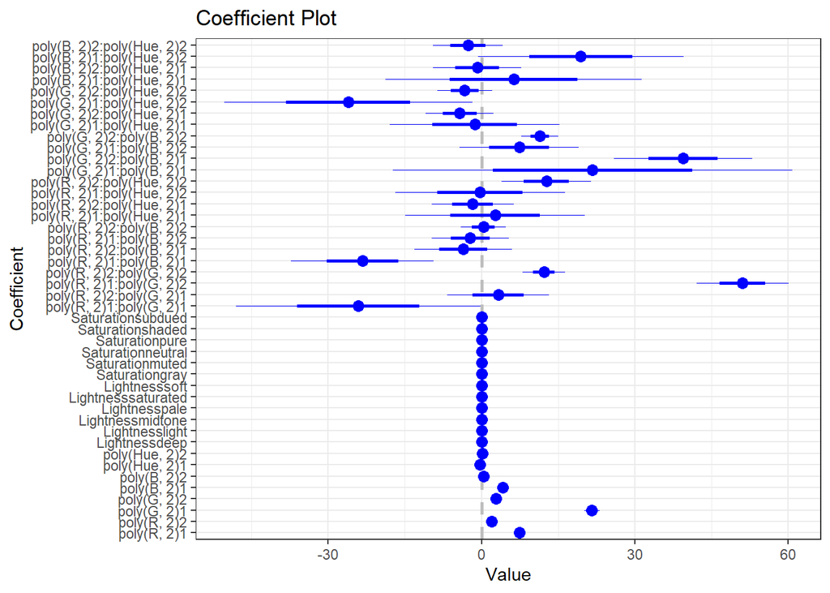

```r
 mod09 %>%
 coefplot::coefplot(intercept = FALSE) +
 theme_bw()
```

```r
 mod09 %>% coef() %>% length()
```

```
## [1] 45
```

```r
 mod09 %>% summary()
```

```
##
## Call:
## lm(formula = y ~ (poly(R, 2) + poly(G, 2) + poly(B, 2) + poly(Hue,
##     2))^2 + Lightness + Saturation, data = dfii)
##
## Residuals:
##      Min       1Q   Median       3Q      Max
## -0.16304 -0.02296 -0.00040  0.02115  0.32021
##
## Coefficients:
##                             Estimate Std. Error t value Pr(>|t|)
## (Intercept)               -1.503e-01  3.616e-02  -4.156 3.59e-05 ***
## poly(R, 2)1                7.486e+00  2.430e-01  30.808  < 2e-16 ***
## poly(R, 2)2                2.018e+00  2.257e-01   8.942  < 2e-16 ***
## poly(G, 2)1                2.165e+01  7.385e-01  29.309  < 2e-16 ***
## poly(G, 2)2                2.887e+00  4.485e-01   6.436 2.13e-10 ***
## poly(B, 2)1                4.161e+00  3.577e-01  11.632  < 2e-16 ***
## poly(B, 2)2                3.906e-01  2.522e-01   1.549 0.121872
## poly(Hue, 2)1             -2.659e-01  1.757e-01  -1.514 0.130502
## poly(Hue, 2)2              1.360e-01  1.365e-01   0.996 0.319365
## Lightnessdeep              7.095e-03  8.471e-03   0.838 0.402546
## Lightnesslight             1.813e-02  1.831e-02   0.990 0.322376
## Lightnessmidtone           3.273e-02  1.572e-02   2.082 0.037675 *
## Lightnesspale              5.784e-02  1.920e-02   3.013 0.002668 **
## Lightnesssaturated         8.112e-03  1.274e-02   0.637 0.524584
## Lightnesssoft              3.189e-02  1.722e-02   1.852 0.064446 .
## Saturationgray             6.739e-03  8.637e-03   0.780 0.435448
## Saturationmuted            6.499e-03  5.616e-03   1.157 0.247478
## Saturationneutral          2.712e-04  7.097e-03   0.038 0.969527
## Saturationpure             1.359e-02  6.181e-03   2.199 0.028152 *
## Saturationshaded           5.305e-03  6.571e-03   0.807 0.419736
## Saturationsubdued          2.266e-03  6.100e-03   0.371 0.710445
## poly(R, 2)1:poly(G, 2)1   -2.417e+01  1.198e+01  -2.017 0.044002 *
## poly(R, 2)2:poly(G, 2)1    3.267e+00  4.990e+00   0.655 0.512928
## poly(R, 2)1:poly(G, 2)2    5.112e+01  4.502e+00  11.354  < 2e-16 ***
## poly(R, 2)2:poly(G, 2)2    1.224e+01  2.094e+00   5.844 7.46e-09 ***
## poly(R, 2)1:poly(B, 2)1   -2.332e+01  6.995e+00  -3.334 0.000897 ***
## poly(R, 2)2:poly(B, 2)1   -3.579e+00  4.755e+00  -0.753 0.451956
## poly(R, 2)1:poly(B, 2)2   -2.190e+00  3.794e+00  -0.577 0.563988
## poly(R, 2)2:poly(B, 2)2    3.862e-01  2.208e+00   0.175 0.861214
## poly(R, 2)1:poly(Hue, 2)1  2.671e+00  8.786e+00   0.304 0.761217
## poly(R, 2)2:poly(Hue, 2)1 -1.718e+00  4.013e+00  -0.428 0.668738
## poly(R, 2)1:poly(Hue, 2)2 -2.772e-01  8.317e+00  -0.033 0.973425
## poly(R, 2)2:poly(Hue, 2)2  1.270e+01  4.402e+00   2.885 0.004015 **
## poly(G, 2)1:poly(B, 2)1    2.175e+01  1.956e+01   1.112 0.266684
## poly(G, 2)2:poly(B, 2)1    3.948e+01  6.780e+00   5.823 8.39e-09 ***
## poly(G, 2)1:poly(B, 2)2    7.379e+00  5.830e+00   1.266 0.206016
## poly(G, 2)2:poly(B, 2)2    1.140e+01  1.813e+00   6.288 5.32e-10 ***
## poly(G, 2)1:poly(Hue, 2)1 -1.293e+00  8.305e+00  -0.156 0.876299
## poly(G, 2)2:poly(Hue, 2)1 -4.271e+00  3.317e+00  -1.288 0.198232
## poly(G, 2)1:poly(Hue, 2)2 -2.609e+01  1.217e+01  -2.144 0.032326 *
## poly(G, 2)2:poly(Hue, 2)2 -3.278e+00  2.699e+00  -1.214 0.224958
## poly(B, 2)1:poly(Hue, 2)1  6.297e+00  1.256e+01   0.501 0.616285
## poly(B, 2)2:poly(Hue, 2)1 -8.452e-01  4.308e+00  -0.196 0.844490
## poly(B, 2)1:poly(Hue, 2)2  1.947e+01  1.005e+01   1.936 0.053174 .
## poly(B, 2)2:poly(Hue, 2)2 -2.637e+00  3.419e+00  -0.771 0.440872
## ---
## Signif. codes:  0 '***' 0.001 '**' 0.01 '*' 0.05 '.' 0.1 ' ' 1
##
## Residual standard error: 0.04104 on 790 degrees of freedom
## Multiple R-squared:  0.9989, Adjusted R-squared:  0.9988
## F-statistic: 1.577e+04 on 44 and 790 DF,  p-value: < 2.2e-16
```

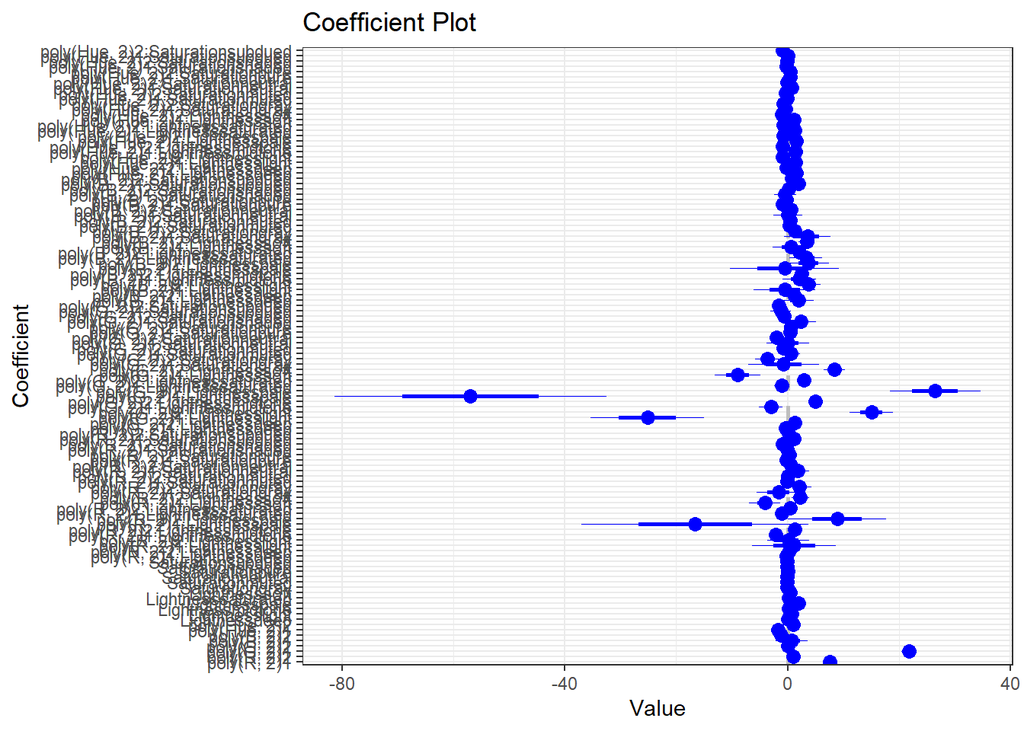

```r
 mod10 %>%
 coefplot::coefplot(intercept = FALSE) +
 theme_bw()
```

```r
 mod10 %>% coef() %>% length()
```

```
## [1] 117
```

```r
 mod10 %>% summary()
```

```
##
## Call:
## lm(formula = y ~ (poly(R, 2) + poly(G, 2) + poly(B, 2) + poly(Hue,
##     2)) * (Lightness + Saturation), data = dfii)
##
## Residuals:
##       Min        1Q    Median        3Q       Max
## -0.222438 -0.021828 -0.001494  0.019609  0.198343
##
## Coefficients:
##                                    Estimate Std. Error t value Pr(>|t|)
## (Intercept)                       -0.231174   0.058422  -3.957 8.35e-05 ***
## poly(R, 2)1                        7.564155   0.364854  20.732  < 2e-16 ***
## poly(R, 2)2                        1.034368   0.179132   5.774 1.15e-08 ***
## poly(G, 2)1                       21.864964   0.674905  32.397  < 2e-16 ***
## poly(G, 2)2                        0.037659   0.303053   0.124 0.901139
## poly(B, 2)1                        0.770870   1.459943   0.528 0.597653
## poly(B, 2)2                       -1.203105   0.512615  -2.347 0.019196 *
## poly(Hue, 2)1                     -1.691331   0.283139  -5.974 3.65e-09 ***
## poly(Hue, 2)2                      0.998514   0.410590   2.432 0.015263 *
## Lightnessdeep                      0.082244   0.058542   1.405 0.160491
## Lightnesslight                     0.813548   0.147196   5.527 4.56e-08 ***
## Lightnessmidtone                   0.256952   0.061344   4.189 3.16e-05 ***
## Lightnesspale                      2.037833   0.313095   6.509 1.42e-10 ***
## Lightnesssaturated                 0.170850   0.059084   2.892 0.003948 **
## Lightnesssoft                      0.478320   0.074907   6.386 3.07e-10 ***
## Saturationgray                    -0.025091   0.018173  -1.381 0.167815
## Saturationmuted                   -0.006484   0.005994  -1.082 0.279688
## Saturationneutral                 -0.016433   0.008457  -1.943 0.052399 .
## Saturationpure                     0.012213   0.007543   1.619 0.105864
## Saturationshaded                  -0.021977   0.007388  -2.975 0.003030 **
## Saturationsubdued                 -0.024750   0.006535  -3.788 0.000165 ***
## poly(R, 2)1:Lightnessdeep         -0.233770   0.339391  -0.689 0.491176
## poly(R, 2)2:Lightnessdeep          0.314720   0.177070   1.777 0.075929 .
## poly(R, 2)1:Lightnesslight         1.170329   3.753033   0.312 0.755256
## poly(R, 2)2:Lightnesslight         0.152799   1.873717   0.082 0.935028
## poly(R, 2)1:Lightnessmidtone      -2.181487   0.561468  -3.885 0.000112 ***
## poly(R, 2)2:Lightnessmidtone       1.287505   0.376607   3.419 0.000665 ***
## poly(R, 2)1:Lightnesspale        -16.606241  10.193015  -1.629 0.103714
## poly(R, 2)2:Lightnesspale          8.917291   4.429947   2.013 0.044492 *
```

[output cut: 79 more lines]

```
## poly(Hue, 2)2:Saturationmuted     -0.324974   0.351925  -0.923 0.356099
## poly(Hue, 2)1:Saturationneutral    0.730872   0.272599   2.681 0.007506 **
## poly(Hue, 2)2:Saturationneutral   -0.127171   0.386043  -0.329 0.741934
## poly(Hue, 2)1:Saturationpure       0.466245   0.240601   1.938 0.053035 .
## poly(Hue, 2)2:Saturationpure       0.460625   0.326588   1.410 0.158850
## poly(Hue, 2)1:Saturationshaded    -0.155056   0.252424  -0.614 0.539233
## poly(Hue, 2)2:Saturationshaded    -0.075502   0.362204  -0.208 0.834936
## poly(Hue, 2)1:Saturationsubdued    0.063983   0.264143   0.242 0.808670
## poly(Hue, 2)2:Saturationsubdued   -0.943218   0.351568  -2.683 0.007467 **
## ---
## Signif. codes:  0 '***' 0.001 '**' 0.01 '*' 0.05 '.' 0.1 ' ' 1
##
## Residual standard error: 0.041 on 718 degrees of freedom
## Multiple R-squared:  0.999,  Adjusted R-squared:  0.9988
## F-statistic:  5994 on 116 and 718 DF,  p-value: < 2.2e-16
```

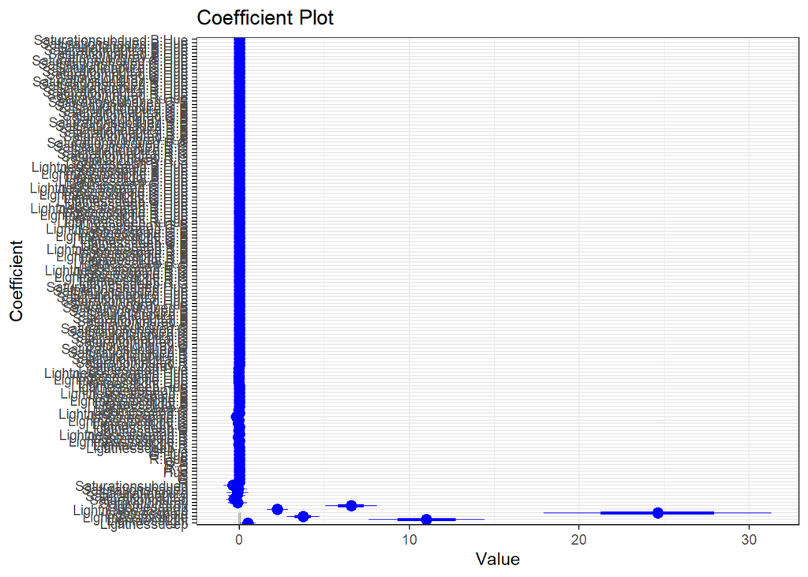

```r
 mod07 %>%
 coefplot::coefplot(intercept = FALSE) +
 theme_bw()
```

```r
 mod07 %>% coef() %>% length()
```

```
## [1] 143
```

```r
 mod07 %>% summary()
```

```
##
## Call:
## lm(formula = y ~ (Lightness + Saturation) * (R + G + B + Hue +
##     R:G + R:B + G:B + R:Hue + G:Hue + B:Hue), data = dfii)
##
## Residuals:
##       Min        1Q    Median        3Q       Max
## -0.233973 -0.023247 -0.001102  0.022124  0.201412
##
## Coefficients:
##                            Estimate Std. Error t value Pr(>|t|)
## (Intercept)              -4.782e+00  3.131e-01 -15.271  < 2e-16 ***
## Lightnessdeep             4.939e-01  2.378e-01   2.077 0.038131 *
## Lightnesslight            1.102e+01  1.708e+00   6.450 2.10e-10 ***
## Lightnessmidtone          3.742e+00  4.747e-01   7.883 1.25e-14 ***
## Lightnesspale             2.460e+01  3.356e+00   7.330 6.45e-13 ***
## Lightnesssaturated        2.235e+00  3.115e-01   7.175 1.86e-12 ***
## Lightnesssoft             6.570e+00  7.647e-01   8.591  < 2e-16 ***
## Saturationgray           -1.148e-01  2.797e-01  -0.411 0.681526
## Saturationmuted          -3.031e-01  2.408e-01  -1.259 0.208560
## Saturationneutral        -1.512e-01  2.568e-01  -0.589 0.556208
## Saturationpure           -1.225e-01  3.184e-01  -0.385 0.700495
## Saturationshaded         -6.223e-02  2.535e-01  -0.245 0.806191
## Saturationsubdued        -3.923e-01  2.611e-01  -1.503 0.133386
## R                         8.432e-03  1.890e-03   4.461 9.53e-06 ***
## G                         1.737e-02  2.291e-03   7.582 1.10e-13 ***
## B                         9.959e-03  2.059e-03   4.837 1.63e-06 ***
## Hue                       8.036e-03  1.264e-02   0.636 0.525200
## R:G                      -1.634e-05  6.036e-06  -2.706 0.006967 **
## R:B                      -1.741e-05  8.436e-06  -2.064 0.039398 *
## G:B                      -1.677e-05  1.342e-05  -1.249 0.211982
## R:Hue                    -3.375e-05  6.661e-05  -0.507 0.612528
## G:Hue                     4.219e-05  5.500e-05   0.767 0.443352
## B:Hue                    -1.305e-04  7.460e-05  -1.749 0.080692 .
## Lightnessdeep:R          -7.922e-04  9.529e-04  -0.831 0.406072
## Lightnesslight:R         -3.478e-02  7.982e-03  -4.357 1.52e-05 ***
## Lightnessmidtone:R       -1.259e-02  2.093e-03  -6.016 2.90e-09 ***
## Lightnesspale:R          -6.586e-02  1.990e-02  -3.309 0.000985 ***
## Lightnesssaturated:R     -8.552e-03  1.366e-03  -6.260 6.76e-10 ***
## Lightnesssoft:R          -1.965e-02  3.593e-03  -5.467 6.39e-08 ***
```

[output cut: 105 more lines]

```
## Saturationpure:G:Hue      5.673e-05  5.768e-05   0.984 0.325650
## Saturationshaded:G:Hue   -2.671e-05  8.560e-05  -0.312 0.755132
## Saturationsubdued:G:Hue  -1.324e-04  7.025e-05  -1.885 0.059787 .
## Saturationgray:B:Hue      2.232e-04  1.531e-04   1.458 0.145257
## Saturationmuted:B:Hue     3.204e-05  5.489e-05   0.584 0.559617
## Saturationneutral:B:Hue   1.738e-04  8.440e-05   2.059 0.039866 *
## Saturationpure:B:Hue     -4.786e-05  6.073e-05  -0.788 0.430981
## Saturationshaded:B:Hue    1.730e-05  7.242e-05   0.239 0.811232
## Saturationsubdued:B:Hue   2.092e-04  6.741e-05   3.103 0.001996 **
## ---
## Signif. codes:  0 '***' 0.001 '**' 0.01 '*' 0.05 '.' 0.1 ' ' 1
##
## Residual standard error: 0.04486 on 692 degrees of freedom
## Multiple R-squared:  0.9988, Adjusted R-squared:  0.9986
## F-statistic:  4089 on 142 and 692 DF,  p-value: < 2.2e-16
```

use the Laplace Approximation approach we used in lecture and the homework assignments. ###

```r
Xmat_mod09 <- model.matrix( formula(mod09), data = dfii )
Xmat_mod04 <- model.matrix( formula(mod04), data = dfii )
```

```r
info_mod09 <- list(
yobs = dfii$y,
design_matrix = Xmat_mod09,
mu_beta = 0,
tau_beta = 1,
sigma_rate = 1
)

info_mod04 <- list(
yobs = dfii$y,
design_matrix = Xmat_mod04,
mu_beta = 0,
tau_beta = 1,
sigma_rate = 1
)
```

```r
lm_logpost <- function(unknowns, my_info)
{
  # specify the number of unknown beta parameters
  length_beta <- ncol(my_info$design_matrix)

  # extract the beta parameters from the `unknowns` vector
  beta_v <- unknowns[1:length_beta]

  # extract the unbounded noise parameter, varphi
  lik_varphi <- unknowns[length_beta + 1]

  # back-transform from varphi to sigma
  lik_sigma <- exp(lik_varphi)

  # extract design matrix
  X <- my_info$design_matrix

  # calculate the linear predictor
  mu <- as.vector( X %*% as.matrix(beta_v) )

  # evaluate the log-likelihood
  log_lik <- sum(dnorm(x = my_info$yobs,
                       mean = mu,
                       sd = lik_sigma,
                       log = TRUE))

  # evaluate the log-prior
  log_prior_beta <- sum(dnorm(x = beta_v,
                              mean = my_info$mu_beta,
                              sd = my_info$tau_beta,
                              log = TRUE))

  log_prior_sigma <- dexp(x = lik_sigma,
                          rate = my_info$sigma_rate,
                          log = TRUE)

  # add the mean trend prior and noise prior together
  log_prior <- log_prior_beta + log_prior_sigma

  # account for the transformation
  log_derive_adjust <- lik_varphi

  # sum together
  log_lik + log_prior + log_derive_adjust
}
```

```r
my_laplace <- function(start_guess, logpost_func, ...)
{
  # code adapted from the `LearnBayes`` function `laplace()`
  fit <- optim(start_guess,
               logpost_func,
               gr = NULL,
               ...,
               method = "BFGS",
               hessian = TRUE,
               control = list(fnscale = -1, maxit = 1001))

  mode <- fit$par
  post_var_matrix <- -solve(fit$hessian)
  p <- length(mode)
  int <- p/2 * log(2 * pi) + 0.5 * log(det(post_var_matrix)) + logpost_func(mode, ...)
  # package all of the results into a list
  list(mode = mode,
       var_matrix = post_var_matrix,
       log_evidence = int,
       converge = ifelse(fit$convergence == 0,
                         "YES",
                         "NO"),
       iter_counts = as.numeric(fit$counts[1]))
}
```

```r
laplace_mod09 <- my_laplace(rep(0, ncol(Xmat_mod09)+1), lm_logpost, info_mod09)
laplace_mod09
```

```
## $mode
##  [1] -0.14888530  8.15256270  1.26073263 21.55278027  1.34275850  5.55342773
##  [7]  1.00146126 -0.13195259 -0.81363477  0.08193779  0.04025964  0.03285003
## [13]  0.13765144  0.07947605  0.01676203 -0.03937245 -0.01130975 -0.04495804
## [19]  0.03563152 -0.03174934 -0.03388148 -1.79086235  2.52949805  7.48301482
## [25]  0.07802133 -0.75220922  1.95531222  3.46808990  0.54705509  0.64269366
## [31]  1.67656973  0.27469353 -1.60544165 -0.19778161  4.86187421  2.66906334
## [37]  0.07591497  1.44466394 -1.69896712 -1.07148132 -0.28135152  0.60142735
## [43] -1.12047257 -0.52238820 -0.88191390 -2.73431032
##
## $var_matrix
##                [,1]          [,2]          [,3]          [,4]          [,5]
##  [1,]  3.218700e-04  7.888691e-04 -2.938492e-04  9.549189e-04 -1.628236e-04
##  [2,]  7.888691e-04  2.651997e-02  3.614711e-03 -1.952152e-02 -2.260430e-03
##  [3,] -2.938492e-04  3.614711e-03  9.630190e-03 -4.715684e-03 -1.103224e-03
```

[output cut: 475 more lines]

```r
laplace_mod04 <- my_laplace(rep(0, ncol(Xmat_mod04)+1), lm_logpost, info_mod04)
laplace_mod04
```

```
## $mode
##  [1] -4.222707966  0.004483560  0.016281289  0.003328133 -0.011592237
##  [6] -0.056859865 -0.171986749  0.098105958 -0.097647292 -0.141339585
## [11] -0.086855937 -0.031911235 -0.070578588  0.043156423 -0.055818839
## [16] -0.059686809 -0.001358464 -2.433269446
##
## $var_matrix
##                [,1]          [,2]          [,3]          [,4]          [,5]
##  [1,]  7.302972e-04 -1.544312e-06 -1.825282e-06 -2.464446e-06  7.418147e-05
##  [2,] -1.544312e-06  1.201619e-08 -6.662606e-09  4.997186e-09 -2.157111e-07
##  [3,] -1.825282e-06 -6.662606e-09  2.739206e-08  7.125210e-10 -5.294587e-07
##  [4,] -2.464446e-06  4.997186e-09  7.125210e-10  2.653347e-08 -7.960579e-07
##  [5,]  7.418147e-05 -2.157111e-07 -5.294587e-07 -7.960579e-07  1.679267e-04
##  [6,]  6.430020e-04 -1.199806e-06 -2.576639e-06 -4.086234e-06  2.556721e-04
##  [7,]  4.184900e-04 -8.051619e-07 -1.796858e-06 -2.792897e-06  1.959890e-04
```

[output cut: 77 more lines]

After fitting the 2 models, you must identify the best model. • Which performance metric did you use to make your selection? ###

```r
models_list <- list(mod09, mod04)
model_names <- c("Model 09", "Model 04")

all_metrics <- map2_dfr(models_list, model_names, extract_metrics, .id = "model_id")
all_metrics %>% glimpse()
```

```
## Rows: 2
## Columns: 14
## $ model_id      <chr> "1", "2"
## $ r.squared     <dbl> 0.9988625, 0.9945082
## $ adj.r.squared <dbl> 0.9987991, 0.9944008
## $ sigma         <dbl> 0.04104213, 0.08862198
## $ statistic     <dbl> 15765.716, 9258.184
## $ p.value       <dbl> 0, 0
## $ df            <dbl> 44, 16
## $ logLik        <dbl> 1504.6008, 847.2924
## $ AIC           <dbl> -2917.202, -1658.585
## $ BIC           <dbl> -2699.740, -1573.491
## $ deviance      <dbl> 1.330720, 6.424454
## $ df.residual   <int> 790, 818
## $ nobs          <int> 835, 835
## $ mod_name      <chr> "Model 09", "Model 04"
```

Sol: mod09 is the best since it has lowest AIC and BIC

Visualize the regression coefficient posterior summary statistics for your best model. ###

```r
viz_post_coefs <- function(post_means, post_sds, xnames)
{
  tibble::tibble(
    mu = post_means,
    sd = post_sds,
    x = xnames
  ) %>%
    mutate(x = factor(x, levels = xnames)) %>%
    ggplot(mapping = aes(x = x)) +
    geom_hline(yintercept = 0, color = 'grey', linetype = 'dashed') +
    geom_point(mapping = aes(y = mu)) +
    geom_linerange(mapping = aes(ymin = mu - 2 * sd,
                                 ymax = mu + 2 * sd,
                                 group = x)) +
    labs(x = 'feature', y = 'coefficient value') +
    coord_flip() +
    theme_bw()
}
```

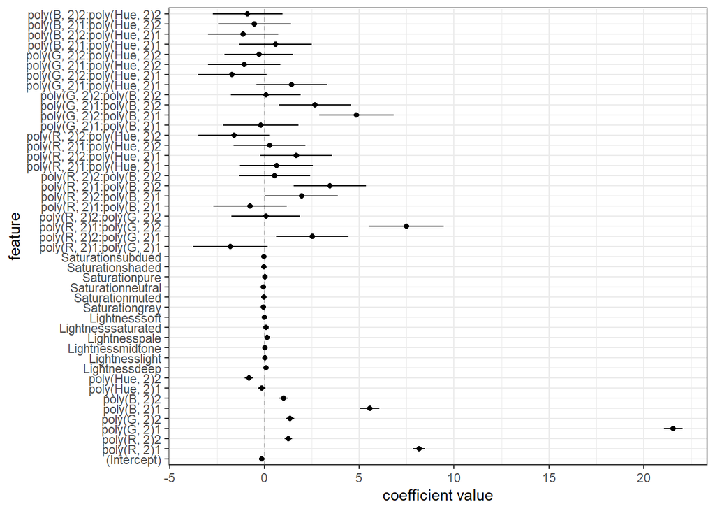

```r
viz_post_coefs(laplace_mod09$mode[1:ncol(Xmat_mod09)],
               sqrt(diag(laplace_mod09$var_matrix)[1:ncol(Xmat_mod09)]),
               colnames(Xmat_mod09))
```

For your best model: Study the posterior UNCERTAINTY on the likelihood noise (residual error), 𝜎. • How does the lm() maximum likelihood estimate (MLE) on 𝜎 relate to the posterior UNCERTAINTY on 𝜎? • Do you feel the posterior is precise or are we quite uncertain about 𝜎? ###

```r
sigma_var <- laplace_mod09$var_matrix[ncol(laplace_mod09$var_matrix), ncol(laplace_mod09$var_matrix)]
sigma_sd <- sqrt(sigma_var)

sigma_mode <- exp(laplace_mod09$mode[length(laplace_mod09$mode)])


z_score <- qnorm(1 - 0.05 / 2)
sigma_lower <- sigma_mode - z_score * sigma_sd
sigma_upper <- sigma_mode + z_score * sigma_sd


sigma_summary <- data.frame(Mode = sigma_mode,
                            StdError = sigma_sd,
                            LowerCI = sigma_lower,
                            UpperCI = sigma_upper)

sigma_summary
```

```
##         Mode   StdError     LowerCI  UpperCI
## 1 0.06493878 0.02844147 0.009194518 0.120683
```

You must make predictions with your 2 selected linear models in order to visualize the trends of the LOGIT-transformed response with respect to the inputs. • You may use non-Bayesian or Bayesian models for the predictions. • You must visualize your predictive trends using the following style: • The primary input should be used as the x-aesthetic in a graphic. • The secondary input should be used as a facet variable – it is recommended to use 4 to 6 unique values if your secondary input is a continuous variable. • You must decide the reference values to use for the remaining inputs. ###

```r
viz_grid <- expand.grid(
  R = seq(min(dfii$R), max(dfii$R), length.out = 101),
  Hue = seq(min(dfii$Hue), max(dfii$Hue), length.out = 9),
  Lightness = unique(dfii$Lightness)[1:4],  # Select distinct values (edit based on your actual data)
  Saturation = unique(dfii$Saturation)[1:4],  # Select distinct values
  G = mean(dfii$G),  # Mean of G as a reference
  B = mean(dfii$B)  # Mean of B as a reference
) %>%
  as.data.frame() %>%
  tibble::as_tibble()

viz_grid %>% glimpse()
```

```
## Rows: 14,544
## Columns: 6
## $ R          <dbl> 0.00, 2.55, 5.10, 7.65, 10.20, 12.75, 15.30, 17.85, 20.40, …
## $ Hue        <dbl> 1, 1, 1, 1, 1, 1, 1, 1, 1, 1, 1, 1, 1, 1, 1, 1, 1, 1, 1, 1,…
## $ Lightness  <fct> dark, dark, dark, dark, dark, dark, dark, dark, dark, dark,…
## $ Saturation <fct> bright, bright, bright, bright, bright, bright, bright, bri…
## $ G          <dbl> 176.3246, 176.3246, 176.3246, 176.3246, 176.3246, 176.3246,…
## $ B          <dbl> 160.3269, 160.3269, 160.3269, 160.3269, 160.3269, 160.3269,…
```

```r
tidy_predict <- function(mod, xnew) {
  pred_df <- predict(mod, newdata = xnew, interval = "confidence") %>%
    as.data.frame() %>%
    tibble::as_tibble() %>%
    select(pred = fit, ci_lwr = lwr, ci_upr = upr) %>%
    bind_cols(predict(mod, newdata = xnew, interval = "prediction") %>%
              as.data.frame() %>%
              tibble::as_tibble() %>%
              select(pred_lwr = lwr, pred_upr = upr))

  xnew %>% bind_cols(pred_df)
}
```

```r
pred_lm_09 <- tidy_predict(mod09, viz_grid)
pred_lm_04 <- tidy_predict(mod04, viz_grid)
pred_lm_09 %>% glimpse()
```

```
## Rows: 14,544
## Columns: 11
## $ R          <dbl> 0.00, 2.55, 5.10, 7.65, 10.20, 12.75, 15.30, 17.85, 20.40, …
## $ Hue        <dbl> 1, 1, 1, 1, 1, 1, 1, 1, 1, 1, 1, 1, 1, 1, 1, 1, 1, 1, 1, 1,…
## $ Lightness  <fct> dark, dark, dark, dark, dark, dark, dark, dark, dark, dark,…
## $ Saturation <fct> bright, bright, bright, bright, bright, bright, bright, bri…
## $ G          <dbl> 176.3246, 176.3246, 176.3246, 176.3246, 176.3246, 176.3246,…
## $ B          <dbl> 160.3269, 160.3269, 160.3269, 160.3269, 160.3269, 160.3269,…
## $ pred       <dbl> -0.3737878, -0.3836937, -0.3932943, -0.4025897, -0.4115798,…
## $ ci_lwr     <dbl> -0.7799423, -0.7805967, -0.7810625, -0.7813396, -0.7814281,…
## $ ci_upr     <dbl> 0.032366632, 0.013209247, -0.005526233, -0.023839805, -0.04…
## $ pred_lwr   <dbl> -0.7878556, -0.7886908, -0.7893433, -0.7898133, -0.7901012,…
## $ pred_upr   <dbl> 0.040279904, 0.021303325, 0.002754579, -0.015366089, -0.033…
```

```r
pred_lm_04 %>% glimpse()
```

```
## Rows: 14,544
## Columns: 11
## $ R          <dbl> 0.00, 2.55, 5.10, 7.65, 10.20, 12.75, 15.30, 17.85, 20.40, …
## $ Hue        <dbl> 1, 1, 1, 1, 1, 1, 1, 1, 1, 1, 1, 1, 1, 1, 1, 1, 1, 1, 1, 1,…
## $ Lightness  <fct> dark, dark, dark, dark, dark, dark, dark, dark, dark, dark,…
## $ Saturation <fct> bright, bright, bright, bright, bright, bright, bright, bri…
## $ G          <dbl> 176.3246, 176.3246, 176.3246, 176.3246, 176.3246, 176.3246,…
## $ B          <dbl> 160.3269, 160.3269, 160.3269, 160.3269, 160.3269, 160.3269,…
## $ pred       <dbl> -0.8193337, -0.8078863, -0.7964389, -0.7849915, -0.7735440,…
## $ ci_lwr     <dbl> -0.8772792, -0.8655058, -0.8537359, -0.8419696, -0.8302069,…
## $ ci_upr     <dbl> -0.7613883, -0.7502668, -0.7391419, -0.7280133, -0.7168812,…
## $ pred_lwr   <dbl> -1.0026843, -0.9911341, -0.9795855, -0.9680386, -0.9564933,…
## $ pred_upr   <dbl> -0.6359832, -0.6246385, -0.6132922, -0.6019443, -0.5905948,…
```

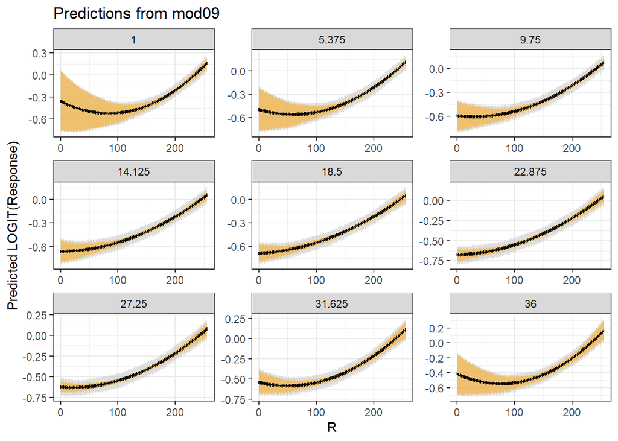

```r
pred_lm_09 %>%
  ggplot(mapping = aes(x = R, y = pred)) +
  geom_ribbon(mapping = aes(ymin = pred_lwr, ymax = pred_upr),
              fill = 'grey',alpha = 0.5) +
  geom_ribbon(mapping = aes(ymin = ci_lwr, ymax = ci_upr),
              fill = 'orange',alpha = 0.5) +
  geom_line(color = 'black') +
  facet_wrap(~Hue, scales = "free") +
  labs(title = "Predictions from mod09", x = "R", y = "Predicted LOGIT(Response)") +
  theme_bw()
```

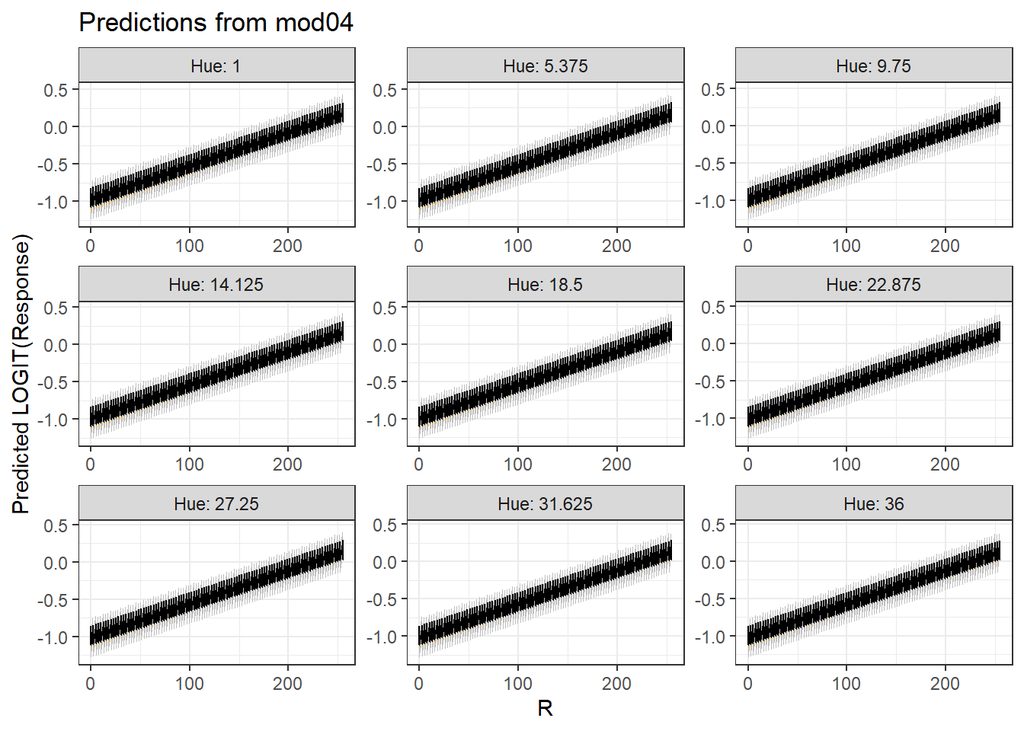

```r
pred_lm_04 %>%
  ggplot(mapping = aes(x = R, y = pred)) +
  geom_ribbon(mapping = aes(ymin = pred_lwr, ymax = pred_upr),
              fill = 'grey') +
  geom_ribbon(mapping = aes(ymin = ci_lwr, ymax = ci_upr),
              fill = 'orange') +
  geom_line(color = 'black') +
  facet_wrap(~Hue, scales = "free",labeller = label_both) +
  labs(title = "Predictions from mod04", x = "R", y = "Predicted LOGIT(Response)") +
  theme_bw()
```

You must train and tune the following models: • Linear models: • All categorical and continuous inputs - linear additive features • Add categorical inputs to all main effect and all pairwise interactions of continuous inputs • The 2 models selected from iiA) (if they are not one of the two above) ### Sol:The models that are considered here are mod04, mod06 and mod09.

```r
formula(mod04)
```

```
## y ~ R + G + B + Lightness + Saturation + Hue
```

```r
formula(mod06)
```

```
## y ~ Lightness + Saturation + R + G + B + Hue + R:G + R:B + G:B +
##     R:Hue + G:Hue + B:Hue
```

```r
formula(mod09)
```

```
## y ~ (poly(R, 2) + poly(G, 2) + poly(B, 2) + poly(Hue, 2))^2 +
##     Lightness + Saturation
```

```r
my_ctrl_A <- trainControl(method = 'repeatedcv', number = 5, repeats = 5)
my_metric_A <- "RMSE"
```

```r
set.seed(2001)
train_mod04 <- train(y ~ R + G + B + Lightness + Saturation + Hue,
                        data = dfii,
                        method = "lm",
                        metric = my_metric_A,
                        trControl = my_ctrl_A)

train_mod04
```

```
## Linear Regression
##
## 835 samples
##   6 predictor
##
## No pre-processing
## Resampling: Cross-Validated (5 fold, repeated 5 times)
## Summary of sample sizes: 668, 668, 669, 667, 668, 669, ...
## Resampling results:
##
##   RMSE        Rsquared   MAE
##   0.08981822  0.9942977  0.06738704
##
## Tuning parameter 'intercept' was held constant at a value of TRUE
```

```r
set.seed(2001)
train_mod06 <- train(y ~ Lightness + Saturation + R + G + B + Hue +
              R:G + R:B + G:B + R:Hue + G:Hue + B:Hue,
                        data = dfii,
                        method = "lm",
                        metric = my_metric_A,
                        trControl = my_ctrl_A)

train_mod06
```

```
## Linear Regression
##
## 835 samples
##   6 predictor
##
## No pre-processing
## Resampling: Cross-Validated (5 fold, repeated 5 times)
## Summary of sample sizes: 668, 668, 669, 667, 668, 669, ...
## Resampling results:
##
##   RMSE        Rsquared   MAE
##   0.08074586  0.9953989  0.06083995
##
## Tuning parameter 'intercept' was held constant at a value of TRUE
```

```r
set.seed(2001)
train_mod09 <- train(y ~ (poly(R, 2) + poly(G, 2) + poly(B, 2) + poly(Hue, 2))^2 + Lightness + Saturation,
                        data = dfii,
                        method = "lm",
                        metric = my_metric_A,
                        trControl = my_ctrl_A)

train_mod09
```

```
## Linear Regression
##
## 835 samples
##   6 predictor
##
## No pre-processing
## Resampling: Cross-Validated (5 fold, repeated 5 times)
## Summary of sample sizes: 668, 668, 669, 667, 668, 669, ...
## Resampling results:
##
##   RMSE        Rsquared   MAE
##   0.04294085  0.9986911  0.0308036
##
## Tuning parameter 'intercept' was held constant at a value of TRUE
```

• Regularized regression with Elastic net • Add categorical inputs to all main effect and all pairwise interactions of continuous inputs • The more complex of the 2 models selected from iiA) ### The models that are considered here are mod06 and mod09.

```r
set.seed(1234)

enet_mod06 <- train(y ~ Lightness + Saturation + R + G + B + Hue +
              R:G + R:B + G:B + R:Hue + G:Hue + B:Hue,
                data = dfii,
                method = 'glmnet',
                metric = my_metric_A,
                preProcess = c("center", "scale"),
                trControl = my_ctrl_A)

enet_mod06
```

```
## glmnet
##
## 835 samples
##   6 predictor
##
## Pre-processing: centered (22), scaled (22)
## Resampling: Cross-Validated (5 fold, repeated 5 times)
## Summary of sample sizes: 668, 668, 668, 668, 668, 668, ...
## Resampling results across tuning parameters:
##
##   alpha  lambda       RMSE        Rsquared   MAE
##   0.10   0.002324946  0.08158141  0.9953253  0.06155450
##   0.10   0.023249462  0.08791956  0.9946260  0.06471344
##   0.10   0.232494618  0.14975492  0.9875419  0.11035823
##   0.55   0.002324946  0.08384222  0.9950511  0.06248310
##   0.55   0.023249462  0.09658776  0.9936704  0.07004785
##   0.55   0.232494618  0.20098793  0.9894171  0.15014569
##   1.00   0.002324946  0.08448043  0.9949784  0.06265891
##   1.00   0.023249462  0.10213868  0.9931015  0.07345257
##   1.00   0.232494618  0.26705132  0.9893931  0.20906690
##
## RMSE was used to select the optimal model using the smallest value.
## The final values used for the model were alpha = 0.1 and lambda = 0.002324946.
```

```r
set.seed(1234)

enet_mod09 <- train(y ~ (poly(R, 2) + poly(G, 2) + poly(B, 2) + poly(Hue, 2))^2 + Lightness + Saturation,
                data = dfii,
                method = 'glmnet',
                metric = my_metric_A,
                preProcess = c("center", "scale"),
                trControl = my_ctrl_A)

enet_mod09
```

```
## glmnet
##
## 835 samples
##   6 predictor
##
## Pre-processing: centered (44), scaled (44)
## Resampling: Cross-Validated (5 fold, repeated 5 times)
## Summary of sample sizes: 668, 668, 668, 668, 668, 668, ...
## Resampling results across tuning parameters:
##
##   alpha  lambda       RMSE        Rsquared   MAE
##   0.10   0.002324946  0.04408803  0.9986294  0.03141709
##   0.10   0.023249462  0.05138863  0.9982136  0.03736389
##   0.10   0.232494618  0.13463947  0.9933947  0.11009484
##   0.55   0.002324946  0.04356971  0.9986600  0.03112274
##   0.55   0.023249462  0.05656002  0.9980419  0.04119444
##   0.55   0.232494618  0.22251501  0.9888069  0.18123908
##   1.00   0.002324946  0.04476599  0.9985874  0.03223194
##   1.00   0.023249462  0.07223861  0.9968381  0.05428787
##   1.00   0.232494618  0.29510544  0.9783940  0.24574432
##
## RMSE was used to select the optimal model using the smallest value.
## The final values used for the model were alpha = 0.55 and lambda = 0.002324946.
```

```r
set.seed(1234)

nnet_mod06 <- train( y ~ Lightness + Saturation + R + G + B + Hue +
              R:G + R:B + G:B + R:Hue + G:Hue + B:Hue,
                       data = dfii,
                       method = 'nnet',
                       metric = my_metric_A,
                       preProcess = c("center", "scale"),
                       trControl = my_ctrl_A,
                       trace = FALSE,
                       linout = TRUE)
nnet_mod06
```

```
## Neural Network
##
## 835 samples
##   6 predictor
##
## Pre-processing: centered (22), scaled (22)
## Resampling: Cross-Validated (5 fold, repeated 5 times)
## Summary of sample sizes: 668, 668, 668, 668, 668, 668, ...
## Resampling results across tuning parameters:
##
##   size  decay  RMSE        Rsquared   MAE
##   1     0e+00  0.18482925  0.9700707  0.12220198
##   1     1e-04  0.18526715  0.9681881  0.12576409
##   1     1e-01  0.11072086  0.9913720  0.08406266
##   3     0e+00  0.06284156  0.9969842  0.04555545
##   3     1e-04  0.07465634  0.9954987  0.05202973
##   3     1e-01  0.06853399  0.9966971  0.04938718
##   5     0e+00  0.05373085  0.9979569  0.03903620
##   5     1e-04  0.05540963  0.9978300  0.03996179
##   5     1e-01  0.06259764  0.9972455  0.04569319
##
## RMSE was used to select the optimal model using the smallest value.
## The final values used for the model were size = 5 and decay = 0.
```

```r
set.seed(1234)

nnet_mod09 <- train( y ~ (poly(R, 2) + poly(G, 2) + poly(B, 2) + poly(Hue, 2))^2 + Lightness + Saturation,
                       data = dfii,
                       method = 'nnet',
                       metric = my_metric_A,
                       preProcess = c("center", "scale"),
                       trControl = my_ctrl_A,
                       trace = FALSE,
                       linout = TRUE)
nnet_mod09
```

```
## Neural Network
##
## 835 samples
##   6 predictor
##
## Pre-processing: centered (44), scaled (44)
## Resampling: Cross-Validated (5 fold, repeated 5 times)
## Summary of sample sizes: 668, 668, 668, 668, 668, 668, ...
## Resampling results across tuning parameters:
##
##   size  decay  RMSE        Rsquared   MAE
##   1     0e+00  0.13299707  0.9826373  0.08448703
##   1     1e-04  0.15964846  0.9681226  0.10559287
##   1     1e-01  0.09920755  0.9920859  0.07068872
##   3     0e+00  0.06460857  0.9968057  0.04505514
##   3     1e-04  0.07514877  0.9953606  0.05199889
##   3     1e-01  0.05421324  0.9979167  0.03883720
##   5     0e+00  0.05570660  0.9977737  0.03863636
##   5     1e-04  0.06250619  0.9971163  0.04244153
##   5     1e-01  0.05103663  0.9981598  0.03679494
##
## RMSE was used to select the optimal model using the smallest value.
## The final values used for the model were size = 5 and decay = 0.1.
```

```r
set.seed(1234)

rf_mod06 <- train( y ~ Lightness + Saturation + R + G + B + Hue +
              R:G + R:B + G:B + R:Hue + G:Hue + B:Hue,
                     data = dfii,
                     method = 'rf',
                     metric = my_metric_A,
                     preProcess = c("center", "scale"),
                     trControl = my_ctrl_A,
                     importance = TRUE)

rf_mod06
```

```
## Random Forest
##
## 835 samples
##   6 predictor
##
## Pre-processing: centered (22), scaled (22)
## Resampling: Cross-Validated (5 fold, repeated 5 times)
## Summary of sample sizes: 668, 668, 668, 668, 668, 668, ...
## Resampling results across tuning parameters:
##
##   mtry  RMSE        Rsquared   MAE
##    2    0.12810842  0.9909668  0.09252154
##   12    0.05568148  0.9978706  0.04020443
##   22    0.06874817  0.9966803  0.04998099
##
## RMSE was used to select the optimal model using the smallest value.
## The final value used for the model was mtry = 12.
```

```r
set.seed(1234)

rf_mod09 <- train( y ~ (poly(R, 2) + poly(G, 2) + poly(B, 2) + poly(Hue, 2))^2 + Lightness + Saturation,
                     data = dfii,
                     method = 'rf',
                     metric = my_metric_A,
                     preProcess = c("center", "scale"),
                     trControl = my_ctrl_A,
                     importance = TRUE)

rf_mod09
```

```
## Random Forest
##
## 835 samples
##   6 predictor
##
## Pre-processing: centered (44), scaled (44)
## Resampling: Cross-Validated (5 fold, repeated 5 times)
## Summary of sample sizes: 668, 668, 668, 668, 668, 668, ...
## Resampling results across tuning parameters:
##
##   mtry  RMSE        Rsquared   MAE
##    2    0.14101655  0.9914504  0.09813568
##   23    0.06825457  0.9968281  0.04841943
##   44    0.07789788  0.9957277  0.05497229
##
## RMSE was used to select the optimal model using the smallest value.
## The final value used for the model was mtry = 23.
```

```r
set.seed(1234)

xgb_mod06 <- train(y ~ Lightness + Saturation + R + G + B + Hue +
              R:G + R:B + G:B + R:Hue + G:Hue + B:Hue,
                   data = dfii,
                   method = 'xgbTree',
                   metric = my_metric_A,
                   trControl = my_ctrl_A,
                   preProcess = c("center", "scale"))
```

[output not shown]

[output cut: 1745 more lines]

[output not shown]

```r
xgb_mod06
```

```
## eXtreme Gradient Boosting
##
## 835 samples
##   6 predictor
##
## Pre-processing: centered (22), scaled (22)
## Resampling: Cross-Validated (5 fold, repeated 5 times)
## Summary of sample sizes: 668, 668, 668, 668, 668, 668, ...
## Resampling results across tuning parameters:
##
##   eta  max_depth  colsample_bytree  subsample  nrounds  RMSE        Rsquared
##   0.3  1          0.6               0.50        50      0.16072958  0.9817054
##   0.3  1          0.6               0.50       100      0.13989135  0.9861927
##   0.3  1          0.6               0.50       150      0.12816107  0.9884359
##   0.3  1          0.6               0.75        50      0.16071924  0.9816802
##   0.3  1          0.6               0.75       100      0.14141743  0.9858338
##   0.3  1          0.6               0.75       150      0.12997755  0.9880523
##   0.3  1          0.6               1.00        50      0.16066322  0.9816621
##   0.3  1          0.6               1.00       100      0.14154860  0.9857789
##   0.3  1          0.6               1.00       150      0.13080244  0.9878568
##   0.3  1          0.8               0.50        50      0.15799465  0.9822437
##   0.3  1          0.8               0.50       100      0.13935322  0.9861831
##   0.3  1          0.8               0.50       150      0.12773841  0.9883997
##   0.3  1          0.8               0.75        50      0.15579724  0.9828689
##   0.3  1          0.8               0.75       100      0.13875899  0.9864045
##   0.3  1          0.8               0.75       150      0.12799045  0.9884235
##   0.3  1          0.8               1.00        50      0.16148524  0.9815931
##   0.3  1          0.8               1.00       100      0.14369538  0.9854378
##   0.3  1          0.8               1.00       150      0.13312491  0.9875160
##   0.3  2          0.6               0.50        50      0.09554084  0.9935414
##   0.3  2          0.6               0.50       100      0.08301448  0.9951322
##   0.3  2          0.6               0.50       150      0.07898014  0.9955964
##   0.3  2          0.6               0.75        50      0.09326842  0.9938085
##   0.3  2          0.6               0.75       100      0.08107036  0.9953337
##   0.3  2          0.6               0.75       150      0.07605963  0.9958981
##   0.3  2          0.6               1.00        50      0.09373098  0.9937617
##   0.3  2          0.6               1.00       100      0.08017474  0.9954507
##   0.3  2          0.6               1.00       150      0.07485827  0.9960299
##   0.3  2          0.8               0.50        50      0.09475649  0.9936448
##   0.3  2          0.8               0.50       100      0.08380739  0.9950420
```

[output cut: 181 more lines]

```
##   0.06706664
##   0.06322368
##   0.05985226
##   0.05908238
##   0.06362851
##   0.06032362
##   0.05958610
##
## Tuning parameter 'gamma' was held constant at a value of 0
## Tuning
##  parameter 'min_child_weight' was held constant at a value of 1
## RMSE was used to select the optimal model using the smallest value.
## The final values used for the model were nrounds = 150, max_depth = 3, eta
##  = 0.3, gamma = 0, colsample_bytree = 0.8, min_child_weight = 1 and subsample
##  = 1.
```

```r
set.seed(1234)

xgb_mod09 <- train( y ~ (poly(R, 2) + poly(G, 2) + poly(B, 2) + poly(Hue, 2))^2 + Lightness + Saturation,
                   data = dfii,
                   method = 'xgbTree',
                   metric = my_metric_A,
                   trControl = my_ctrl_A,
                   preProcess = c("center", "scale"))
```

[output not shown]

[output cut: 1745 more lines]

[output not shown]

```r
xgb_mod09
```

```
## eXtreme Gradient Boosting
##
## 835 samples
##   6 predictor
##
## Pre-processing: centered (44), scaled (44)
## Resampling: Cross-Validated (5 fold, repeated 5 times)
## Summary of sample sizes: 668, 668, 668, 668, 668, 668, ...
## Resampling results across tuning parameters:
##
##   eta  max_depth  colsample_bytree  subsample  nrounds  RMSE        Rsquared
##   0.3  1          0.6               0.50        50      0.14497477  0.9851141
##   0.3  1          0.6               0.50       100      0.12771814  0.9884365
##   0.3  1          0.6               0.50       150      0.12039001  0.9897350
##   0.3  1          0.6               0.75        50      0.14088707  0.9858465
##   0.3  1          0.6               0.75       100      0.12354758  0.9891568
##   0.3  1          0.6               0.75       150      0.11489845  0.9906299
##   0.3  1          0.6               1.00        50      0.14398302  0.9852027
##   0.3  1          0.6               1.00       100      0.12521231  0.9888340
##   0.3  1          0.6               1.00       150      0.11477240  0.9906371
##   0.3  1          0.8               0.50        50      0.13473303  0.9870417
##   0.3  1          0.8               0.50       100      0.11948242  0.9898657
##   0.3  1          0.8               0.50       150      0.11270287  0.9909860
##   0.3  1          0.8               0.75        50      0.13535207  0.9868900
##   0.3  1          0.8               0.75       100      0.11972757  0.9897649
##   0.3  1          0.8               0.75       150      0.11141661  0.9911349
##   0.3  1          0.8               1.00        50      0.13253359  0.9874561
##   0.3  1          0.8               1.00       100      0.11687023  0.9902752
##   0.3  1          0.8               1.00       150      0.10792626  0.9917120
##   0.3  2          0.6               0.50        50      0.10288480  0.9923934
##   0.3  2          0.6               0.50       100      0.09559128  0.9934572
##   0.3  2          0.6               0.50       150      0.09293877  0.9938280
##   0.3  2          0.6               0.75        50      0.10298236  0.9924506
##   0.3  2          0.6               0.75       100      0.09415342  0.9936930
##   0.3  2          0.6               0.75       150      0.09141840  0.9940521
##   0.3  2          0.6               1.00        50      0.09840219  0.9931363
##   0.3  2          0.6               1.00       100      0.08998427  0.9942601
##   0.3  2          0.6               1.00       150      0.08677699  0.9946512
##   0.3  2          0.8               0.50        50      0.09417301  0.9937060
##   0.3  2          0.8               0.50       100      0.08877496  0.9943939
```

[output cut: 181 more lines]

```
##   0.07350914
##   0.06837110
##   0.06686025
##   0.06642848
##   0.06803513
##   0.06617098
##   0.06575476
##
## Tuning parameter 'gamma' was held constant at a value of 0
## Tuning
##  parameter 'min_child_weight' was held constant at a value of 1
## RMSE was used to select the optimal model using the smallest value.
## The final values used for the model were nrounds = 150, max_depth = 3, eta
##  = 0.3, gamma = 0, colsample_bytree = 0.8, min_child_weight = 1 and subsample
##  = 1.
```

• 2 methods of your choice that we did not explicitly discuss in lecture You must use ALL categorical and continuous inputs with the non-linear methods ###

```r
my_ctrl <- trainControl(
  method = "cv",
  number = 5,
  savePredictions = "final",
  summaryFunction = defaultSummary
)

my_metric <- "RMSE"
```

```r
svm_mod06 <- train(y ~ Lightness + Saturation + R + G + B + Hue +
              R:G + R:B + G:B + R:Hue + G:Hue + B:Hue,
  data = dfii,
  method = "svmRadial",  # using radial basis function kernel
  metric = my_metric,       # replace RMSE with your metric, e.g., my_metric_A
  trControl = my_ctrl,
  preProcess = c("center", "scale")
)

svm_mod06
```

```
## Support Vector Machines with Radial Basis Function Kernel
##
## 835 samples
##   6 predictor
##
## Pre-processing: centered (22), scaled (22)
## Resampling: Cross-Validated (5 fold)
## Summary of sample sizes: 668, 668, 667, 668, 669
## Resampling results across tuning parameters:
##
##   C     RMSE       Rsquared   MAE
##   0.25  0.1330155  0.9881540  0.09864943
##   0.50  0.1133243  0.9911739  0.08511014
##   1.00  0.1016163  0.9929393  0.07738298
##
## Tuning parameter 'sigma' was held constant at a value of 0.03344983
## RMSE was used to select the optimal model using the smallest value.
## The final values used for the model were sigma = 0.03344983 and C = 1.
```

```r
svm_mod09 <- train(y ~ (poly(R, 2) + poly(G, 2) + poly(B, 2) + poly(Hue, 2))^2 + Lightness + Saturation,
  data = dfii,
  method = "svmRadial",  # using radial basis function kernel
  metric = my_metric,       # replace RMSE with your metric, e.g., my_metric_A
  trControl = my_ctrl,
  preProcess = c("center", "scale")
)
svm_mod09
```

```
## Support Vector Machines with Radial Basis Function Kernel
##
## 835 samples
##   6 predictor
##
## Pre-processing: centered (44), scaled (44)
## Resampling: Cross-Validated (5 fold)
## Summary of sample sizes: 667, 669, 668, 668, 668
## Resampling results across tuning parameters:
##
##   C     RMSE       Rsquared   MAE
##   0.25  0.1525041  0.9862529  0.10119032
##   0.50  0.1313075  0.9891197  0.08682679
##   1.00  0.1209943  0.9905883  0.08194655
##
## Tuning parameter 'sigma' was held constant at a value of 0.0153765
## RMSE was used to select the optimal model using the smallest value.
## The final values used for the model were sigma = 0.0153765 and C = 1.
```

```r
knn_mod06 <- train(y ~ Lightness + Saturation + R + G + B + Hue +
              R:G + R:B + G:B + R:Hue + G:Hue + B:Hue,
  data = dfii,
  method = "knn",
  metric = my_metric,
  trControl = my_ctrl,
  preProcess = c("center", "scale"),
  tuneLength = 10
)
knn_mod06
```

```
## k-Nearest Neighbors
##
## 835 samples
##   6 predictor
##
## Pre-processing: centered (22), scaled (22)
## Resampling: Cross-Validated (5 fold)
## Summary of sample sizes: 668, 668, 667, 668, 669
## Resampling results across tuning parameters:
##
##   k   RMSE       Rsquared   MAE
##    5  0.2654038  0.9508965  0.2050927
##    7  0.2805534  0.9453113  0.2219529
##    9  0.2873806  0.9424406  0.2299521
##   11  0.2877742  0.9420361  0.2326885
##   13  0.2876921  0.9421025  0.2299117
##   15  0.2870876  0.9424862  0.2284112
##   17  0.2879016  0.9424643  0.2288755
##   19  0.2869488  0.9430769  0.2270500
##   21  0.2864141  0.9436652  0.2250557
##   23  0.2863092  0.9438294  0.2243545
##
## RMSE was used to select the optimal model using the smallest value.
## The final value used for the model was k = 5.
```

```r
knn_mod09 <- train(y ~ (poly(R, 2) + poly(G, 2) + poly(B, 2) + poly(Hue, 2))^2 + Lightness + Saturation,
  data = dfii,
  method = "knn",
  metric = my_metric,
  trControl = my_ctrl,
  preProcess = c("center", "scale"),
  tuneLength = 10
)
knn_mod09
```

```
## k-Nearest Neighbors
##
## 835 samples
##   6 predictor
##
## Pre-processing: centered (44), scaled (44)
## Resampling: Cross-Validated (5 fold)
## Summary of sample sizes: 668, 667, 668, 668, 669
## Resampling results across tuning parameters:
##
##   k   RMSE       Rsquared   MAE
##    5  0.1862415  0.9757319  0.1461547
##    7  0.1832394  0.9767399  0.1458724
##    9  0.1789491  0.9782620  0.1440508
##   11  0.1801588  0.9782460  0.1443962
##   13  0.1795816  0.9787648  0.1444860
##   15  0.1821709  0.9785554  0.1474191
##   17  0.1834516  0.9786288  0.1484663
##   19  0.1859436  0.9785784  0.1504411
##   21  0.1894295  0.9782090  0.1535687
##   23  0.1927306  0.9779494  0.1565854
##
## RMSE was used to select the optimal model using the smallest value.
## The final value used for the model was k = 9.
```

• You must decide the resampling scheme. • That resampling scheme must be applied to ALL models! ### Sol: 5 fold cross validation is used

• Different models have different preprocessing requirements. • You must decide the appropriate preprocessing options you should consider. • You must identify the performance metrics you will focus on to compare the models. • You must identify the best model. ### Sol: RMSE is used as performance metric. According to rmse values, mod09 is the best model